# Contacts

Kendra Wyant

2021-07-02

### Notes

Purpose: This file reads in all individual excel contact files from participants’ raw data folders and creates an aggregate data file. Light EDA is also included as part of this cleaning script.

Inputs:  
[subid]_Contacts.xlsx

Output:  
contacts.csv

### Setup

Paths

```r
path_raw <- "/Volumes/private/studydata/risk/data_raw"
path_shared <- "/Volumes/private/studydata/risk/data_processed/shared"
path_log <- "~/analysis_risk1/shared/notes"
```

Packages and Source

```r
library(tidyverse)
library(kableExtra)
library(readxl)
library(lubridate)
library(janitor)

theme_set(theme_classic())

source("~/lab_support/fun_phone_numbers.R")
```

### Create function

```r
read_contacts <- function(subid) {
    file <- list.files(file.path(path_raw, subid), pattern = "Contacts", include.dirs = FALSE)
    if(length(file) > 0) {
      path <- file.path(path_raw, subid, file)
      log <- read_excel(file.path(path)) %>%
             mutate(across(everything(), as.character), # for merging
                    subid = as.numeric(subid))
      return(log)
    }
}
```

### Get subids

```r
subids <- list.dirs(path_raw, recursive = FALSE, full.names = FALSE) %>%
  keep(~ str_detect(.x, "([0-2][0-9][0-9])")) %>%
  enframe(name = NULL, value = "subid")
```

### Read in data and glimpse

```r
contacts <- map_df(subids$subid, ~read_contacts(.)) %>%
  glimpse()
```

```
## Rows: 7,291
## Columns: 18
## $ UTC                <chr> "1487871000", "1487871000", "1487871000", "1487871…
## $ HomePhone          <chr> NA, "6082227282", NA, NA, NA, NA, NA, NA, NA, NA, …
## $ CellPhone          <chr> "6083588174", NA, "6085149557", "6084385017", "608…
## $ OtherPhone1        <chr> NA, NA, NA, NA, NA, NA, NA, NA, NA, NA, NA, NA, NA…
## $ OtherPhone2        <chr> NA, NA, NA, NA, NA, NA, NA, NA, NA, NA, NA, NA, NA…
## $ Type               <chr> "Self", "Parent", "Other", "Friend", "Co-Worker/Bu…
## $ ContactDrankPast   <chr> NA, "Never/Almost Never", "Never/Almost Never", "N…
## $ DrinkStatus        <chr> NA, "Drinker", "NonDrinker", "NonDrinker", "Dont K…
## $ ContactDrinkFuture <chr> NA, "Yes", "No", "No", "No", "Yes", "Yes", "No", "…
## $ Recovery           <chr> NA, "No", "Yes", "Dont Know", "Yes", "No", "No", "…
## $ SupportStatus      <chr> NA, "Supportive", "Neutral", "Supportive", "Suppor…
## $ ContactExperience  <chr> NA, "Mixed", "Mixed", "Pleasant", "Pleasant", "Ple…
## $ MonthlyVisit       <chr> NA, NA, NA, NA, NA, NA, NA, NA, NA, NA, NA, NA, NA…
## $ StreetAddress      <chr> NA, NA, NA, NA, NA, NA, NA, NA, NA, NA, NA, NA, NA…
## $ City               <chr> NA, NA, NA, NA, NA, NA, NA, NA, NA, NA, NA, NA, NA…
## $ State              <chr> NA, NA, NA, NA, NA, NA, NA, NA, NA, NA, NA, NA, NA…
## $ subid              <dbl> 1, 1, 1, 1, 1, 1, 1, 1, 1, 2, 2, 2, 2, 2, 2, 2, 2,…
## $ `City State`       <chr> NA, NA, NA, NA, NA, NA, NA, NA, NA, NA, NA, NA, NA…
```

### Clean data from log

cleaning function

```r
clean_contacts <- function(d, log){
  # recode_one log entries
  log_recode_one <- filter(log, log_action == "recode_one")

  for (i in seq_along(log_recode_one$index)){

    log_subid <- pluck(log_recode_one, "subid", i)
    log_var_name <- pluck(log_recode_one, "var_name", i)
    log_new_value <- pluck(log_recode_one, "new_value", i)
    log_old_value <- pluck(log_recode_one, "old_value", i)

    # check that only one matching data row
    if (is.na(log_old_value)) {
      row_id <- d %>%
      mutate(row_number = as.numeric(rownames(d))) %>%
      filter(subid == log_subid) %>%
      filter(is.na(get(log_var_name))) %>%
      select(row_number) %>%
      unlist(use.names = FALSE)
    } else {
      row_id <- d %>%
      mutate(row_number = as.numeric(rownames(d))) %>%
      filter(subid == log_subid) %>%
      filter(get(log_var_name) == log_old_value) %>%
      select(row_number) %>%
      unlist(use.names = FALSE)
    }

    if (length(row_id) != 1) {
      stop("Rows matching subid: ", log_subid, " does not equal 1")
    }

    # make change to rowid
    if (is.numeric(d[[ row_id, log_var_name]])) d[[ row_id, log_var_name]] <- as.numeric(log_new_value)
    if (is_character(d[[ row_id, log_var_name]])) d[[ row_id, log_var_name]] <- as.character(log_new_value)
    if (is.POSIXt(d[[ row_id, log_var_name]])) d[[ row_id, log_var_name]] <- as_datetime(log_new_value)

  }

  # recode_all entries
  # Involves changing recurrent typo patterns in variable response labels
  log_recode_all <- filter(log, log_action == "recode_all")

  for (i in seq_along(log_recode_all$index)){

    log_var_name <- pluck(log_recode_all, "var_name", i)
    log_new_value <- pluck(log_recode_all, "new_value", i)
    log_old_value <- pluck(log_recode_all, "old_value", i)

    # pull out row ids that need to be recoded
    row_ids <- d %>%
      mutate(row_number = as.numeric(rownames(d))) %>%
      filter(get(log_var_name) == log_old_value) %>%
      select(row_number) %>%
      unlist(use.names = FALSE)

    for (i in seq_along(row_ids)) {

      if (is.numeric(d[[ row_ids[i], log_var_name]])) d[[ row_ids[i], log_var_name]] <- as.numeric(log_new_value)
      if (is_character(d[[ row_ids[i], log_var_name]])) d[[ row_ids[i], log_var_name]] <- as.character(log_new_value)
      if (is.POSIXt(d[[ row_ids[i], log_var_name]])) d[[ row_ids[i], log_var_name]] <- as_datetime(log_new_value)
    }
  }

  return(d)
}
```

read in log and summarize

```r
log <- read_csv(file.path(path_log, "log_contacts.csv"), col_types = cols()) %>%
  rowid_to_column("index") %>%
  glimpse()
```

```
## Rows: 18
## Columns: 8
## $ index      <int> 1, 2, 3, 4, 5, 6, 7, 8, 9, 10, 11, 12, 13, 14, 15, 16, 17,…
## $ subid      <dbl> 24, 17, NA, NA, NA, NA, 19, 28, 182, NA, NA, 134, 16, 87, …
## $ var_name   <chr> "UTC", "Type", "Type", "Type", "Type", "Type", "Type", "Co…
## $ old_value  <chr> NA, "Co-Worker", "Co-Worker/Business contact", "Co-Worker/…
## $ new_value  <chr> "1510243200", "Co-Worker/Business Contact", "Co-Worker/Bus…
## $ log_action <chr> "recode_one", "recode_one", "recode_all", "recode_all", "r…
## $ source     <chr> "EDA Kendra", "EDA Kendra", "EDA Kendra", "EDA Kendra", "E…
## $ notes      <chr> "All contacts have same utc except for the first entry (\"…
```

```r
# view log actions
table(log$log_action)
```

```
##
##       note recode_all recode_one
##          3          7          8
```

```r
# print notes
log %>%
  filter(log_action == "note") %>%
  kbl() %>%
  kable_styling(bootstrap_options = c("condensed"))
```

| index | subid | var_name | old_value | new_value | log_action | source | notes |
| --- | --- | --- | --- | --- | --- | --- | --- |
| 13 | 16 | SupportStatus | No | NA | note | EDA Kendra | No is not a valid response option - we do not have enough info to resolve this error though so it will be a project-level pre-processing decision of how to handle |
| 14 | 87 | SupportStatus | No | NA | note | EDA Kendra | No is not a valid response option - we do not have enough info to resolve this error though so it will be a project-level pre-processing decision of how to handle |
| 15 | 33 | ContactExperience | Unpleasant/mixed | NA | note | EDA Kendra | Unpleasant/mixed is not a valid response option - we do not have enough info to resolve this error though so it will be a project-level pre-processing decision of how to handle |

clean data

```r
contacts <- contacts %>%
  clean_contacts(., log) %>%
  glimpse()
```

```
## Rows: 7,291
## Columns: 18
## $ UTC                <chr> "1487871000", "1487871000", "1487871000", "1487871…
## $ HomePhone          <chr> NA, "6082227282", NA, NA, NA, NA, NA, NA, NA, NA, …
## $ CellPhone          <chr> "6083588174", NA, "6085149557", "6084385017", "608…
## $ OtherPhone1        <chr> NA, NA, NA, NA, NA, NA, NA, NA, NA, NA, NA, NA, NA…
## $ OtherPhone2        <chr> NA, NA, NA, NA, NA, NA, NA, NA, NA, NA, NA, NA, NA…
## $ Type               <chr> "Self", "Parent", "Other", "Friend", "Co-Worker/Bu…
## $ ContactDrankPast   <chr> NA, "Never/Almost Never", "Never/Almost Never", "N…
## $ DrinkStatus        <chr> NA, "Drinker", "NonDrinker", "NonDrinker", "Dont K…
## $ ContactDrinkFuture <chr> NA, "Yes", "No", "No", "No", "Yes", "Yes", "No", "…
## $ Recovery           <chr> NA, "No", "Yes", "Dont Know", "Yes", "No", "No", "…
## $ SupportStatus      <chr> NA, "Supportive", "Neutral", "Supportive", "Suppor…
## $ ContactExperience  <chr> NA, "Mixed", "Mixed", "Pleasant", "Pleasant", "Ple…
## $ MonthlyVisit       <chr> NA, NA, NA, NA, NA, NA, NA, NA, NA, NA, NA, NA, NA…
## $ StreetAddress      <chr> NA, NA, NA, NA, NA, NA, NA, NA, NA, NA, NA, NA, NA…
## $ City               <chr> NA, NA, NA, NA, NA, NA, NA, NA, NA, NA, NA, NA, NA…
## $ State              <chr> NA, NA, NA, NA, NA, NA, NA, NA, NA, NA, NA, NA, NA…
## $ subid              <dbl> 1, 1, 1, 1, 1, 1, 1, 1, 1, 2, 2, 2, 2, 2, 2, 2, 2,…
## $ `City State`       <chr> NA, NA, NA, NA, NA, NA, NA, NA, NA, NA, NA, NA, NA…
```

### tidy data

Tidy variable names

```r
contacts <- contacts %>%
  clean_names() %>%
  glimpse()
```

```
## Rows: 7,291
## Columns: 18
## $ utc                  <chr> "1487871000", "1487871000", "1487871000", "14878…
## $ home_phone           <chr> NA, "6082227282", NA, NA, NA, NA, NA, NA, NA, NA…
## $ cell_phone           <chr> "6083588174", NA, "6085149557", "6084385017", "6…
## $ other_phone1         <chr> NA, NA, NA, NA, NA, NA, NA, NA, NA, NA, NA, NA, …
## $ other_phone2         <chr> NA, NA, NA, NA, NA, NA, NA, NA, NA, NA, NA, NA, …
## $ type                 <chr> "Self", "Parent", "Other", "Friend", "Co-Worker/…
## $ contact_drank_past   <chr> NA, "Never/Almost Never", "Never/Almost Never", …
## $ drink_status         <chr> NA, "Drinker", "NonDrinker", "NonDrinker", "Dont…
## $ contact_drink_future <chr> NA, "Yes", "No", "No", "No", "Yes", "Yes", "No",…
## $ recovery             <chr> NA, "No", "Yes", "Dont Know", "Yes", "No", "No",…
## $ support_status       <chr> NA, "Supportive", "Neutral", "Supportive", "Supp…
## $ contact_experience   <chr> NA, "Mixed", "Mixed", "Pleasant", "Pleasant", "P…
## $ monthly_visit        <chr> NA, NA, NA, NA, NA, NA, NA, NA, NA, NA, NA, NA, …
## $ street_address       <chr> NA, NA, NA, NA, NA, NA, NA, NA, NA, NA, NA, NA, …
## $ city                 <chr> NA, NA, NA, NA, NA, NA, NA, NA, NA, NA, NA, NA, …
## $ state                <chr> NA, NA, NA, NA, NA, NA, NA, NA, NA, NA, NA, NA, …
## $ subid                <dbl> 1, 1, 1, 1, 1, 1, 1, 1, 1, 2, 2, 2, 2, 2, 2, 2, …
## $ city_state           <chr> NA, NA, NA, NA, NA, NA, NA, NA, NA, NA, NA, NA, …
```

Check for any legitimate missing phone numbers before transforming dataframe to long

```r
contacts %>%
  filter(is.na(home_phone) & is.na(cell_phone) & is.na(other_phone1) & is.na(other_phone2)) %>%
  kbl() %>%
  kable_styling() %>%
  scroll_box(width = "100%")
```

| utc | home_phone | cell_phone | other_phone1 | other_phone2 | type | contact_drank_past | drink_status | contact_drink_future | recovery | support_status | contact_experience | monthly_visit | street_address | city | state | subid | city_state |
| --- | --- | --- | --- | --- | --- | --- | --- | --- | --- | --- | --- | --- | --- | --- | --- | --- | --- |
| 1519331400 | NA | NA | NA | NA | Friend | Almost Always/Always | Drinker | Yes | Dont Know | Dont Know | Mixed | No | NA | NA | NA | 41 | NA |

```r
# Temporarily turn NA into character to preserve
contacts <- contacts %>%
  mutate(cell_phone = case_when(subid == 41 & is.na(cell_phone) & is.na(other_phone1) ~ "NA",
                                TRUE ~ cell_phone))
```

pivot longer and reorder variables

```r
contacts <- contacts %>%
  pivot_longer(home_phone:other_phone2, names_to = "phone_type", values_to = "phone_number") %>%
  filter(!is.na(phone_number)) %>%
  select(subid, utc, contact_type = type, phone_type, phone_number, contact_drank_past:state, utc) %>%
  glimpse()
```

```
## Rows: 7,421
## Columns: 15
## $ subid                <dbl> 1, 1, 1, 1, 1, 1, 1, 1, 1, 2, 2, 2, 2, 2, 2, 2, …
## $ utc                  <chr> "1487871000", "1487871000", "1487871000", "14878…
## $ contact_type         <chr> "Self", "Parent", "Other", "Friend", "Co-Worker/…
## $ phone_type           <chr> "cell_phone", "home_phone", "cell_phone", "cell_…
## $ phone_number         <chr> "6083588174", "6082227282", "6085149557", "60843…
## $ contact_drank_past   <chr> NA, "Never/Almost Never", "Never/Almost Never", …
## $ drink_status         <chr> NA, "Drinker", "NonDrinker", "NonDrinker", "Dont…
## $ contact_drink_future <chr> NA, "Yes", "No", "No", "No", "Yes", "Yes", "No",…
## $ recovery             <chr> NA, "No", "Yes", "Dont Know", "Yes", "No", "No",…
## $ support_status       <chr> NA, "Supportive", "Neutral", "Supportive", "Supp…
## $ contact_experience   <chr> NA, "Mixed", "Mixed", "Pleasant", "Pleasant", "P…
## $ monthly_visit        <chr> NA, NA, NA, NA, NA, NA, NA, NA, NA, NA, NA, NA, …
## $ street_address       <chr> NA, NA, NA, NA, NA, NA, NA, NA, NA, NA, NA, NA, …
## $ city                 <chr> NA, NA, NA, NA, NA, NA, NA, NA, NA, NA, NA, NA, …
## $ state                <chr> NA, NA, NA, NA, NA, NA, NA, NA, NA, NA, NA, NA, …
```

replace all string NAs to actual missing value NAs

```r
contacts <- contacts %>%
  naniar::replace_with_na_if(.predicate = is.character, condition = ~.x == "NA")
```

### EDA

169 subids have contact information.

Check to see who completed intake that don’t have contacts  
NOTE: Subids 8 and 235 do not have a contacts file

```r
visit_dates <- read_csv(file.path(path_shared, "visit_dates.csv"), col_types = cols())
notes <- read_csv(file.path(path_raw, "raw_notes.csv"), col_types = cols()) %>%
  select(subid, notes_general)

visit_dates %>%
  filter(!is.na(intake)) %>%
  filter(!subid %in% as.numeric(contacts$subid))
```

```
## # A tibble: 2 x 8
##   subid screen     intake     start_study followup_1 followup_2 end_study
##   <dbl> <date>     <date>     <date>      <date>     <date>     <date>
## 1     8 2017-06-13 2017-06-28 2017-06-29  NA         NA         2017-07-13
## 2   235 2019-05-28 2019-06-20 2019-06-21  NA         NA         2019-06-21
## # … with 1 more variable: final_visit <date>
```

```r
notes %>%
  filter(subid %in% c(8, 235)) %>%
  kbl() %>%
  kable_styling()
```

| subid | notes_general |
| --- | --- |
| 8 | No show for FU #1 - Unable to continue participation due to family crisis.; from screen session - We are still conferring on eligibility. We will let the participant know by Friday whether they are ab… |
| 235 | No EMA or audio data; Participant dropped out first on study day; rescheduled intake once before completing |

NOTE: subid 67 has contacts but never completed intake/started study - leaving contacts in because they will be filtered out at the project-level depending on final sample

```r
intake <- visit_dates %>%
  filter(!is.na(intake))
contacts %>%
  filter(!as.numeric(subid) %in% intake$subid)
```

```
## # A tibble: 5 x 15
##   subid utc   contact_type phone_type phone_number contact_drank_p… drink_status
##   <dbl> <chr> <chr>        <chr>      <chr>        <chr>            <chr>
## 1    67 1526… Self         cell_phone 6176334533   <NA>             <NA>
## 2    67 1526… Sibling      cell_phone 6176336533   Occasionally     Drinker
## 3    67 1526… Parent       cell_phone 7817752577   Never/Almost Ne… NonDrinker
## 4    67 1526… Other        cell_phone 6084459064   Never/Almost Ne… NonDrinker
## 5    67 1526… Friend       cell_phone 5082093336   Almost Always/A… Drinker
## # … with 8 more variables: contact_drink_future <chr>, recovery <chr>,
## #   support_status <chr>, contact_experience <chr>, monthly_visit <chr>,
## #   street_address <chr>, city <chr>, state <chr>
```

```r
visit_dates %>%
  filter(subid == 67)
```

```
## # A tibble: 1 x 8
##   subid screen     intake     start_study followup_1 followup_2 end_study
##   <dbl> <date>     <date>     <date>      <date>     <date>     <date>
## 1    67 2018-05-14 NA         NA          NA         NA         NA
## # … with 1 more variable: final_visit <date>
```

```r
notes %>%
  filter(subid == 67) %>%
  kbl() %>%
  kable_styling()
```

| subid | notes_general |
| --- | --- |
| 67 | Originally came in for intake on 5-21-18 but the participant did not have an eligible phone. He was supposed to bring in his new phone as his old phone is a Samsung Galaxy 4 and we can not use it in o… |

Check for duplicate entries  
FIX: Some duplicates are errors (2 entries on same date with discrepant answers) and some are not (updating address, home phone number belongs to 2 parents, etc.)  
NOTE: leaving as project-level pre-processing decision of how to handle error and non-error duplicates

```r
# filter out identical entries
contacts <- contacts %>%
  distinct(across(-utc), .keep_all = TRUE)

# count duplicate numbers listed for each subid
duplicates <- contacts %>%
  group_by(subid, phone_number) %>%
  summarise(n = n()) %>%
  filter(n > 1)
print(duplicates, n = Inf)
```

```
## # A tibble: 19 x 3
## # Groups:   subid [15]
##    subid phone_number     n
##    <dbl> <chr>        <int>
##  1    24 6082227742       2
##  2    33 6088735039       2
##  3    61 6083474657       2
##  4    86 6304275562       2
##  5    97 6086433393       2
##  6   104 6084693159       2
##  7   109 6305611375       2
##  8   110 4148819604       2
##  9   117 6085987543       2
## 10   119 6082398865       2
## 11   139 6082137652       2
## 12   143 6082828270       2
## 13   240 9204509643       2
## 14   248 6084452342       2
## 15   248 6086695757       2
## 16   248 6088432572       2
## 17   248 9062815847       2
## 18   269 6083473760       2
## 19   269 6309131339       2
```

```r
contacts %>%
  filter(phone_number %in% duplicates$phone_number & subid %in% duplicates$subid) %>%
  arrange(subid, phone_number) %>%
  kbl() %>%
  kable_styling(bootstrap_options = c("condensed", "striped")) %>%
  scroll_box(width = "100%", height = "500px")
```

| subid | utc | contact_type | phone_type | phone_number | contact_drank_past | drink_status | contact_drink_future | recovery | support_status | contact_experience | monthly_visit | street_address | city | state |
| --- | --- | --- | --- | --- | --- | --- | --- | --- | --- | --- | --- | --- | --- | --- |
| 24 | 1510243200 | Parent | home_phone | 6082227742 | Never/Almost Never | Drinker | No | No | Supportive | Mixed | NA | NA | NA | NA |
| 24 | 1510243200 | Parent | home_phone | 6082227742 | Never/Almost Never | Drinker | Yes | No | Supportive | Mixed | NA | NA | NA | NA |
| 33 | 1512493200 | Irrelevant/Spam | other_phone1 | 6088735039 | NA | NA | NA | NA | NA | NA | NA | NA | NA | NA |
| 33 | 1519146600 | Other | cell_phone | 6088735039 | NA | NA | NA | NA | NA | NA | NA | NA | NA | NA |
| 61 | 1523634900 | Friend | cell_phone | 6083474657 | Never/Almost Never | Dont Know | No | Dont Know | Dont Know | Pleasant | No | NA | NA | NA |
| 61 | 1523634900 | Friend | cell_phone | 6083474657 | Never/Almost Never | Dont Know | No | Dont Know | Dont Know | Pleasant | Yes | 3007 Bryn Wood Drive | Fitchburg | WI |
| 86 | 1531924200 | Friend | cell_phone | 6304275562 | Occasionally | Drinker | Yes | No | Mixed | Pleasant | No | NA | NA | NA |
| 86 | 1534779600 | Friend | cell_phone | 6304275562 | Never/Almost Never | Drinker | Yes | No | Dont Know | Pleasant | Yes | 642 State Street | Madison | WI |
| 97 | 1532449800 | Irrelevant/Spam | home_phone | 6086433393 | NA | NA | NA | NA | NA | NA | NA | NA | NA | NA |
| 97 | 1537889400 | Irrelevant/Spam | other_phone1 | 6086433393 | NA | NA | NA | NA | NA | NA | NA | NA | NA | NA |
| 104 | 1535133600 | Family-Other | cell_phone | 6084693159 | Never/Almost Never | Drinker | No | No | Supportive | Pleasant | Yes | 1910 Manley Street | Madison | WI |
| 104 | 1537991280 | Family-Other | cell_phone | 6084693159 | Occasionally | Drinker | No | No | Supportive | Pleasant | No | NA | NA | NA |
| 109 | 1537819200 | Friend | cell_phone | 6305611375 | Occasionally | Drinker | Yes | No | Dont Know | Pleasant | No | NA | NA | NA |
| 109 | 1542036600 | Irrelevant/Spam | other_phone1 | 6305611375 | NA | NA | NA | NA | NA | NA | NA | NA | NA | NA |
| 110 | 1534531200 | Self | cell_phone | 4148819604 | NA | NA | NA | NA | NA | NA | NA | NA | NA | NA |
| 110 | 1534531200 | Friend | cell_phone | 4148819604 | Occasionally | Drinker | Yes | No | Dont Know | Mixed | Yes | 133 West Oregon Street | Milwaukee | WI |
| 117 | 1538685000 | Co-Worker/Business Contact | cell_phone | 6085987543 | Never/Almost Never | NonDrinker | No | No | Dont Know | Pleasant | No | NA | NA | NA |
| 117 | 1544475600 | Friend | cell_phone | 6085987543 | Never/Almost Never | Drinker | Yes | Yes | Dont Know | Pleasant | Yes | 4817 Sheboygan Avenue | Madison | WI |
| 119 | 1540397820 | Irrelevant/Spam | other_phone2 | 6082398865 | NA | NA | NA | NA | NA | NA | NA | NA | NA | NA |
| 119 | 1543252500 | Friend | cell_phone | 6082398865 | Occasionally | Drinker | Yes | No | Mixed | Mixed | No | NA | NA | NA |
| 139 | 1539799200 | Self | cell_phone | 6082137652 | NA | NA | NA | NA | NA | NA | NA | NA | NA | NA |
| 139 | 1548171000 | Irrelevant/Spam | other_phone1 | 6082137652 | NA | NA | NA | NA | NA | NA | NA | NA | NA | NA |
| 143 | 1538762400 | Counselor | cell_phone | 6082828270 | Never/Almost Never | Dont Know | No | Dont Know | Supportive | Pleasant | No | NA | NA | NA |
| 143 | 1541790000 | Irrelevant/Spam | other_phone1 | 6082828270 | NA | NA | NA | NA | NA | NA | NA | NA | NA | NA |
| 240 | 1561474800 | Spouse/Significant Other | cell_phone | 9204509643 | Occasionally | Drinker | Uncertain | No | Supportive | Pleasant | Yes | 930 Emerald Street | Madison | WI |
| 240 | 1566831600 | Spouse/Significant Other | cell_phone | 9204509643 | Occasionally | Drinker | Uncertain | No | Supportive | Pleasant | Yes | 4537 Thurston Lane | Fitchburg | WI |
| 248 | 1565722800 | Friend | cell_phone | 6084452342 | Occasionally | Drinker | Yes | No | Dont Know | Pleasant | No | NA | NA | NA |
| 248 | 1568314800 | Friend | cell_phone | 6084452342 | Occasionally | Drinker | Yes | No | Neutral | Pleasant | No | NA | NA | NA |
| 248 | 1565722800 | Aunt/Uncle | cell_phone | 6086695757 | Occasionally | NonDrinker | No | No | Dont Know | Pleasant | No | NA | NA | NA |
| 248 | 1568314800 | Aunt/Uncle | cell_phone | 6086695757 | Occasionally | Drinker | Uncertain | No | Supportive | Pleasant | No | NA | NA | NA |
| 248 | 1565722800 | Friend | cell_phone | 6088432572 | Occasionally | Drinker | Yes | No | Supportive | Pleasant | No | NA | NA | NA |
| 248 | 1568314800 | Friend | cell_phone | 6088432572 | Occasionally | Drinker | Yes | No | Dont Know | Pleasant | No | NA | NA | NA |
| 248 | 1565722800 | Friend | cell_phone | 9062815847 | Occasionally | Drinker | Yes | No | Supportive | Neutral | No | NA | NA | NA |
| 248 | 1568314800 | Friend | cell_phone | 9062815847 | Almost Always/Always | Drinker | Yes | No | Mixed | Mixed | No | NA | NA | NA |
| 269 | 1567105200 | Counselor | home_phone | 6082828270 | Never/Almost Never | Dont Know | No | Dont Know | Supportive | Pleasant | No | NA | NA | NA |
| 269 | 1569856800 | Friend | cell_phone | 6083473760 | Occasionally | Drinker | Uncertain | No | Supportive | Pleasant | No | NA | NA | NA |
| 269 | 1573150500 | Irrelevant/Spam | other_phone1 | 6083473760 | NA | NA | NA | NA | NA | NA | NA | NA | NA | NA |
| 269 | 1569856800 | Family-Other | cell_phone | 6309131339 | Never/Almost Never | Drinker | Uncertain | No | Supportive | Pleasant | No | NA | NA | NA |
| 269 | 1575567600 | Family-Other | cell_phone | 6309131339 | Never/Almost Never | Dont Know | Uncertain | No | Supportive | Pleasant | No | NA | NA | NA |

#### Missing data

```r
naniar::miss_var_summary(contacts)
```

```
## # A tibble: 15 x 3
##    variable             n_miss pct_miss
##    <chr>                 <int>    <dbl>
##  1 street_address         6853  92.4
##  2 city                   6848  92.4
##  3 state                  6848  92.4
##  4 monthly_visit          2611  35.2
##  5 contact_drink_future   2418  32.6
##  6 recovery               2418  32.6
##  7 contact_drank_past     2415  32.6
##  8 drink_status           2415  32.6
##  9 support_status         2415  32.6
## 10 contact_experience     2414  32.6
## 11 contact_type              3   0.0405
## 12 phone_number              2   0.0270
## 13 subid                     0   0
## 14 utc                       0   0
## 15 phone_type                0   0
```

2 Missing phone numbers

```r
contacts %>%
  filter(is.na(phone_number))
```

```
## # A tibble: 2 x 15
##   subid utc   contact_type phone_type phone_number contact_drank_p… drink_status
##   <dbl> <chr> <chr>        <chr>      <chr>        <chr>            <chr>
## 1    41 1519… Friend       cell_phone <NA>         Almost Always/A… Drinker
## 2    81 1530… Spouse/Sign… cell_phone <NA>         Occasionally     Drinker
## # … with 8 more variables: contact_drink_future <chr>, recovery <chr>,
## #   support_status <chr>, contact_experience <chr>, monthly_visit <chr>,
## #   street_address <chr>, city <chr>, state <chr>
```

- subid 81: from data log - “Participant’s partner is incarcerated. She reported that all of the phone calls that come up as restricted or unknown are incoming calls from her partner. She reported that she speaks to him frequently.” Also, note the state is Illinois which might give some clues as to which unknown/restricted numbers are him
- subid 41: No info as to why this number is blank

Missing contact type values have an actual NA in the excel file - what could this mean?

```r
contacts %>%
  filter(is.na(contact_type)) %>%
  kbl() %>%
  kable_styling(bootstrap_options = c("condensed", "striped")) %>%
  column_spec(3, color = "red") %>%
  scroll_box(width = "100%")
```

| subid | utc | contact_type | phone_type | phone_number | contact_drank_past | drink_status | contact_drink_future | recovery | support_status | contact_experience | monthly_visit | street_address | city | state |
| --- | --- | --- | --- | --- | --- | --- | --- | --- | --- | --- | --- | --- | --- | --- |
| 16 | 1513783800 | NA | cell_phone | 6085163702 | Never/Almost Never | NonDrinker | No | No | Dont Know | Pleasant | No | NA | NA | NA |
| 18 | 1516309200 | NA | cell_phone | 6082359642 | Almost Always/Always | Drinker | Yes | No | Dont Know | Pleasant | No | NA | NA | NA |
| 56 | 1531317600 | NA | cell_phone | 6083457045 | Occasionally | Drinker | No | No | Supportive | Pleasant | No | NA | NA | NA |

```r
contacts %>%
  filter(is.na(recovery)) %>%
  filter(contact_type != "Self" & contact_type != "Irrelevant/Spam" & contact_type != "Other") %>%
  kbl() %>%
  kable_styling(bootstrap_options = c("condensed", "striped")) %>%
  scroll_box(width = "100%", height = "500px")
```

| subid | utc | contact_type | phone_type | phone_number | contact_drank_past | drink_status | contact_drink_future | recovery | support_status | contact_experience | monthly_visit | street_address | city | state |
| --- | --- | --- | --- | --- | --- | --- | --- | --- | --- | --- | --- | --- | --- | --- |
| 6 | 1497465000 | Counselor | other_phone1 | 6088374814 | NA | NA | NA | NA | NA | NA | Yes | 1460 West Main Street | Sun Prarie | WI |
| 18 | 1516309200 | Co-Worker/Business Contact | home_phone | 6088498385 | NA | NA | NA | NA | NA | NA | NA | NA | NA | NA |
| 26 | 1513200600 | Family-Other | cell_phone | 6082283374 | NA | NA | NA | NA | NA | NA | NA | NA | NA | NA |
| 26 | 1513200600 | Friend | home_phone | 7736993784 | NA | NA | NA | NA | NA | NA | NA | NA | NA | NA |
| 26 | 1513200600 | Friend | cell_phone | 3128414983 | NA | NA | NA | NA | NA | NA | NA | NA | NA | NA |
| 26 | 1513200600 | Friend | other_phone1 | 4242394294 | NA | NA | NA | NA | NA | NA | NA | NA | NA | NA |
| 26 | 1513200600 | Friend | cell_phone | 8052940369 | NA | NA | NA | NA | NA | NA | NA | NA | NA | NA |
| 33 | 1519146600 | Co-Worker/Business Contact | cell_phone | 6082407426 | NA | NA | NA | NA | NA | NA | NA | NA | NA | NA |
| 64 | 1533915900 | Social Worker/Case Manager | home_phone | 6082572542 | NA | NA | NA | NA | NA | NA | NA | NA | NA | NA |
| 66 | 1526578200 | Cousin | cell_phone | 6176028982 | Almost Always/Always | NonDrinker | No | NA | Unsupportive | NA | No | NA | NA | NA |
| 66 | 1528992000 | Friend | cell_phone | 6082138473 | Never/Almost Never | Dont Know | NA | NA | Neutral | Neutral | No | NA | NA | NA |
| 66 | 1531843200 | Family-Other | cell_phone | 6304867412 | NA | NA | NA | NA | Dont Know | NA | NA | NA | NA | NA |
| 66 | 1531843200 | Family-Other | cell_phone | 6084512714 | NA | NA | NA | NA | NA | NA | NA | NA | NA | NA |
| 77 | 1535468400 | Co-Worker/Business Contact | home_phone | 6082407504 | NA | NA | NA | NA | NA | NA | NA | NA | NA | NA |
| 118 | 1539788400 | Friend | cell_phone | 3478395351 | Occasionally | Drinker | Yes | NA | NA | Pleasant | No | NA | NA | NA |
| 143 | 1538762400 | Friend | cell_phone | 6088077658 | NA | NA | NA | NA | NA | NA | NA | NA | NA | NA |

#### contact type

```r
contacts %>%
  tabyl(contact_type)
```

```
##                contact_type    n      percent valid_percent
##                  Aunt/Uncle  105 0.0141643059   0.014170040
##                       Child  133 0.0179414542   0.017948718
##  Co-Worker/Business Contact  725 0.0978011601   0.097840756
##                   Counselor   63 0.0084985836   0.008502024
##                      Cousin   89 0.0120059355   0.012010796
##                Family-Other  249 0.0335896398   0.033603239
##                      Friend 2412 0.3253743424   0.325506073
##                 Grandparent   32 0.0043167409   0.004318489
##             Irrelevant/Spam 2212 0.2983947120   0.298515520
##                       Other  525 0.0708215297   0.070850202
##                      Parent  267 0.0360178066   0.036032389
##                        Self  182 0.0245514636   0.024561404
##                     Sibling  253 0.0341292324   0.034143050
##  Social Worker/Case Manager   38 0.0051261298   0.005128205
##    Spouse/Significant Other  125 0.0168622690   0.016869096
##                        <NA>    3 0.0004046945            NA
```

#### Phone numbers

Raw number format

```r
contacts %>%
  filter(!is.na(phone_number)) %>%
  select(phone_number) %>%
  print(n = Inf)
```

```
## # A tibble: 7,411 x 1
##      phone_number
##      <chr>
##    1 6083588174
##    2 6082227282
##    3 6085149557
##    4 6084385017
##    5 6082131910
##    6 6082205506
##    7 6087125499
##    8 6085091830
##    9 6082138880
##   10 6085134796
##   11 6084696114
##   12 6084388784
```

[output cut: 7399 more lines]

Check for non-numeric characters

```r
contacts %>%
  filter(str_detect(phone_number, "[[:space:][:punct:][:alpha:]]")) %>%
  select(phone_number)
```

```
## # A tibble: 0 x 1
## # … with 1 variable: phone_number <chr>
```

Numbers not 10 digits  
Only 3 are known contacts

```r
contacts %>%
  select(subid, phone_number, contact_type) %>%
  filter(str_length(phone_number) != 10) %>%
  print(n = Inf)
```

```
## # A tibble: 26 x 3
##    subid phone_number contact_type
##    <dbl> <chr>        <chr>
##  1    21 21525        Irrelevant/Spam
##  2    21 67283        Irrelevant/Spam
##  3    21 89289        Irrelevant/Spam
##  4    30 67578        Irrelevant/Spam
##  5    30 262966       Irrelevant/Spam
##  6    33 1113114      Irrelevant/Spam
##  7    34 622622       Irrelevant/Spam
##  8    58 21525        Irrelevant/Spam
##  9    66 60837550     Irrelevant/Spam
## 10    76 622622       Irrelevant/Spam
## 11    76 77887        Irrelevant/Spam
## 12    76 89885        Irrelevant/Spam
## 13    85 71976        Irrelevant/Spam
## 14    94 573153065078 Spouse/Significant Other
## 15   110 622622       Irrelevant/Spam
## 16   110 21525        Irrelevant/Spam
## 17   117 917838348876 Parent
## 18   117 919811021816 Social Worker/Case Manager
## 19   158 21525        Irrelevant/Spam
## 20   166 89289        Irrelevant/Spam
## 21   166 800050001020 Irrelevant/Spam
## 22   179 67587        Irrelevant/Spam
## 23   234 288472       Irrelevant/Spam
## 24   243 47272        Irrelevant/Spam
## 25   243 692632       Irrelevant/Spam
## 26   255 622622       Other
```

Filter out short codes

```r
contacts %>%
  select(subid, phone_number, contact_type) %>%
  filter(str_length(phone_number) != 10) %>%
  filter(str_length(phone_number) != 5 & str_length(phone_number) != 6) %>%
  print(n = Inf)
```

```
## # A tibble: 6 x 3
##   subid phone_number contact_type
##   <dbl> <chr>        <chr>
## 1    33 1113114      Irrelevant/Spam
## 2    66 60837550     Irrelevant/Spam
## 3    94 573153065078 Spouse/Significant Other
## 4   117 917838348876 Parent
## 5   117 919811021816 Social Worker/Case Manager
## 6   166 800050001020 Irrelevant/Spam
```

Check country code on these numbers

```r
numbers <- contacts %>%
  filter(str_length(phone_number) != 10) %>%
  filter(str_length(phone_number) != 5 & str_length(phone_number) != 6) %>%
  select(phone_number) %>%
  unlist(use.names = FALSE)

valid_country_code <- NULL

for (i in 1:length(numbers)) {
  if(check_country_code(numbers[i])) {
     valid_country_code <- append(valid_country_code, numbers[i])
  }
}

valid_country_code
```

```
## [1] "573153065078" "917838348876" "919811021816"
```

Check area code for all 10 digit numbers  
Print numbers without valid area code

```r
numbers <- contacts %>%
  filter(str_length(phone_number) == 10) %>%
  select(phone_number) %>%
  unlist(use.names = FALSE)

not_valid_area_code <- NULL

for (i in 1:length(numbers)) {
  if(!check_area_code(numbers[i])) {
     not_valid_area_code <- append(not_valid_area_code, numbers[i])
  }
}

contacts %>%
  filter(phone_number %in% not_valid_area_code) %>%
  select(subid, phone_number, contact_type) %>%
  print(n = Inf)
```

```
## # A tibble: 22 x 3
##    subid phone_number contact_type
##    <dbl> <chr>        <chr>
##  1    29 6008904796   Irrelevant/Spam
##  2    76 4745227703   Parent
##  3    80 1121611611   Irrelevant/Spam
##  4    87 4924174643   Parent
##  5   110 4446142226   Friend
##  6   117 8861744325   Co-Worker/Business Contact
##  7   117 9811789353   Parent
##  8   117 4461229000   Irrelevant/Spam
##  9   117 9650630332   Friend
## 10   117 9654274797   Family-Other
## 11   117 9933112838   Co-Worker/Business Contact
## 12   117 9572158706   Co-Worker/Business Contact
## 13   117 9980224137   Other
## 14   117 9611399594   Friend
## 15   117 9685004720   Co-Worker/Business Contact
## 16   117 7838348876   Parent
## 17   117 9990723933   Friend
## 18   117 9811021816   Aunt/Uncle
## 19   117 8800298233   Friend
## 20   150 1121611611   Irrelevant/Spam
## 21   180 4822214772   Other
## 22   191 3585496515   Irrelevant/Spam
```

FIX: 600 area code under subid 29 is probably supposed to be 608 since 600 is not a valid US area code and no log entries exist with that area code

```r
logs <- read_csv(file.path(path_shared, "voice_ios.csv"), col_types = "iTiiiiiniiiincccccccTTcc") %>%
  glimpse()
```

```
## Rows: 52,434
## Columns: 24
## $ subid                         <int> 1, 1, 1, 1, 1, 1, 1, 1, 1, 1, 1, 1, 1, …
## $ zdate                         <dttm> 2017-04-30 15:33:35, 2017-05-01 14:07:…
## $ z_pk                          <int> 367, 368, 369, 370, 489, 490, 506, 507,…
## $ z_opt                         <int> 1, 1, 1, 1, 1, 1, 2, 2, 2, 2, 2, 1, 1, …
## $ zanswered                     <int> 0, 0, 0, 0, 1, 1, 0, 0, 0, 0, 0, 1, 0, …
## $ zcall_category                <int> 1, 1, 1, 1, 1, 1, 1, 1, 1, 1, 1, 1, 1, …
## $ zcalltype                     <int> 1, 1, 1, 1, 1, 1, 1, 1, 1, 1, 1, 1, 1, …
## $ zface_time_data               <dbl> NA, NA, NA, NA, NA, NA, NA, NA, NA, NA,…
## $ zhandle_type                  <int> 2, 2, 2, 2, 2, 2, 2, 2, 2, 2, 2, 2, 2, …
## $ znumber_availability          <int> 0, 0, 0, 0, 0, 0, 0, 0, 0, 0, 0, 0, 0, …
## $ zoriginated                   <int> 1, 1, 1, 1, 0, 0, 0, 0, 0, 0, 0, 0, 1, …
## $ zread                         <int> 1, 1, 1, 1, 1, 1, 1, 1, 1, 1, 1, 1, 1, …
## $ zduration                     <dbl> 44, 19, 41, 0, 61, 41, 0, 0, 0, 0, 0, 1…
## $ ziso_country_code             <chr> "us", "us", "us", "us", "us", "us", "us…
## $ zlocation                     <chr> "<<RecentsNumberLocationNotFound>>", "M…
## $ zname                         <chr> NA, NA, NA, NA, NA, NA, NA, NA, NA, NA,…
## $ zservice_provider             <chr> "com.apple.Telephony", "com.apple.Telep…
## $ zunique_id                    <chr> "3E1FC317-9330-41AF-81CA-F3BCEFC11AF1",…
## $ zaddress                      <chr> "5091830", "6088904796", "4385017", "16…
## $ log_file                      <chr> "001_Voice_1.sql", "001_Voice_1.sql", "…
## $ created                       <dttm> 2017-11-16 20:35:34, 2017-11-16 20:35:…
## $ modified                      <dttm> 2017-11-16 20:42:41, 2017-11-16 20:42:…
## $ zlocalparticipantuuid         <chr> NA, NA, NA, NA, NA, NA, NA, NA, NA, NA,…
## $ zoutgoinglocalparticipantuuid <chr> NA, NA, NA, NA, NA, NA, NA, NA, NA, NA,…
```

```r
logs %>%
  filter(zaddress == "6008904796") %>%
  select(subid, zaddress)
```

```
## # A tibble: 0 x 2
## # … with 2 variables: subid <int>, zaddress <chr>
```

```r
logs %>%
  filter(zaddress == "6088904796") %>%
  filter(subid == 29) %>%
  select(subid, zaddress)
```

```
## # A tibble: 10 x 2
##    subid zaddress
##    <int> <chr>
##  1    29 6088904796
##  2    29 6088904796
##  3    29 6088904796
##  4    29 6088904796
##  5    29 6088904796
##  6    29 6088904796
##  7    29 6088904796
##  8    29 6088904796
##  9    29 6088904796
## 10    29 6088904796
```

No contacts already listed as this number for subid 29

```r
contacts %>%
  filter(phone_number == "6088904796") %>%
  filter(subid == "029")
```

```
## # A tibble: 0 x 15
## # … with 15 variables: subid <dbl>, utc <chr>, contact_type <chr>,
## #   phone_type <chr>, phone_number <chr>, contact_drank_past <chr>,
## #   drink_status <chr>, contact_drink_future <chr>, recovery <chr>,
## #   support_status <chr>, contact_experience <chr>, monthly_visit <chr>,
## #   street_address <chr>, city <chr>, state <chr>
```

Filter out spam from other numbers with invalid area codes

```r
contacts %>%
  filter(phone_number %in% not_valid_area_code) %>%
  select(subid, phone_number, contact_type) %>%
  filter(contact_type != "Irrelevant/Spam" & contact_type != "Other") %>%
  print(n = Inf)
```

```
## # A tibble: 15 x 3
##    subid phone_number contact_type
##    <dbl> <chr>        <chr>
##  1    76 4745227703   Parent
##  2    87 4924174643   Parent
##  3   110 4446142226   Friend
##  4   117 8861744325   Co-Worker/Business Contact
##  5   117 9811789353   Parent
##  6   117 9650630332   Friend
##  7   117 9654274797   Family-Other
##  8   117 9933112838   Co-Worker/Business Contact
##  9   117 9572158706   Co-Worker/Business Contact
## 10   117 9611399594   Friend
## 11   117 9685004720   Co-Worker/Business Contact
## 12   117 7838348876   Parent
## 13   117 9990723933   Friend
## 14   117 9811021816   Aunt/Uncle
## 15   117 8800298233   Friend
```

Check country codes for international numbers

```r
numbers <- contacts %>%
  filter(phone_number %in% not_valid_area_code) %>%
  filter(contact_type != "Irrelevant/Spam" & contact_type != "Other") %>%
  select(phone_number) %>%
  unlist(use.names = FALSE)

valid_country_code <- NULL

for (i in 1:length(not_valid_area_code)) {
  if(check_country_code(not_valid_area_code[i])) {
     valid_country_code <- append(valid_country_code, not_valid_area_code[i])
  }
}

valid_country_code
```

```
## [1] "4924174643"
```

```r
contacts %>%
  filter(phone_number %in% not_valid_area_code) %>%
  filter(!phone_number %in% valid_country_code) %>%
  select(subid, phone_number, contact_type) %>%
  filter(contact_type != "Irrelevant/Spam" & contact_type != "Other") %>%
  print(n = Inf)
```

```
## # A tibble: 14 x 3
##    subid phone_number contact_type
##    <dbl> <chr>        <chr>
##  1    76 4745227703   Parent
##  2   110 4446142226   Friend
##  3   117 8861744325   Co-Worker/Business Contact
##  4   117 9811789353   Parent
##  5   117 9650630332   Friend
##  6   117 9654274797   Family-Other
##  7   117 9933112838   Co-Worker/Business Contact
##  8   117 9572158706   Co-Worker/Business Contact
##  9   117 9611399594   Friend
## 10   117 9685004720   Co-Worker/Business Contact
## 11   117 7838348876   Parent
## 12   117 9990723933   Friend
## 13   117 9811021816   Aunt/Uncle
## 14   117 8800298233   Friend
```

#### Monthly visit

NOTE: monthly visit means participant visits home of contact at least monthly

```r
contacts %>%
  tabyl(monthly_visit)
```

```
##  monthly_visit    n    percent valid_percent
##             No 4237 0.57156347     0.8823407
##            Yes  565 0.07621746     0.1176593
##           <NA> 2611 0.35221907            NA
```

Should have been gathering addresses when monthly_visit = yes  
We have addresses for all but 11 of the contacts who participants visited monthly

```r
contacts %>%
  filter(monthly_visit == "Yes") %>%
  count(!is.na(street_address))
```

```
## # A tibble: 2 x 2
##   `!is.na(street_address)`     n
## * <lgl>                    <int>
## 1 FALSE                       11
## 2 TRUE                       554
```

```r
contacts %>%
  filter(monthly_visit == "Yes") %>%
  filter(!is.na(street_address)) %>%
  select(subid, contact_type, street_address, city, state) %>%
  print(n = Inf)
```

```
## # A tibble: 554 x 5
##     subid contact_type           street_address               city         state
##     <dbl> <chr>                  <chr>                        <chr>        <chr>
##   1     6 Parent                 773 North Water Street       Milwaukee    WI
##   2     6 Sibling                227 Langdon Street           Madison      WI
##   3     6 Parent                 14995 Kings Ridge Court      Brookfield   WI
##   4     6 Friend                 10 North Orchard Street      Madison      WI
##   5     6 Friend                 621 Orchard Drive            Madison      WI
##   6     6 Aunt/Uncle             773 North Water Street       Milwaukee    WI
##   7     6 Other                  6001 Research Park Blvd.     Madison      WI
##   8     6 Counselor              1460 West Main Street        Sun Prarie   WI
##   9    11 Friend                 22 Langdon Street            Madison      WI
##  10    11 Parent                 3715 North 54th Boulevard    Milwaukee    WI
##  11    11 Parent                 3715 North 54th Boulevard    Milwaukee    WI
##  12    11 Sibling                3715 North 54th Boulevard    Milwaukee    WI
```

[output cut: 542 more lines]

Locations for other contacts  
We only have 6 address for contacts that don’t have monthly_visit as yes

```r
contacts %>%
  filter(monthly_visit == "No" | is.na(monthly_visit)) %>%
  count(!is.na(street_address))
```

```
## # A tibble: 2 x 2
##   `!is.na(street_address)`     n
## * <lgl>                    <int>
## 1 FALSE                     6842
## 2 TRUE                         6
```

#### Context variables

```r
contacts %>%
  tabyl(contact_drank_past)
```

```
##    contact_drank_past    n    percent valid_percent
##  Almost Always/Always  691 0.09321462     0.1382553
##    Never/Almost Never 2692 0.36314582     0.5386154
##          Occasionally 1615 0.21786052     0.3231293
##                  <NA> 2415 0.32577904            NA
```

```r
contacts %>%
  tabyl(drink_status)
```

```
##  drink_status    n   percent valid_percent
##     Dont Know 1116 0.1505463     0.2232893
##       Drinker 2843 0.3835154     0.5688275
##    NonDrinker 1039 0.1401592     0.2078832
##          <NA> 2415 0.3257790            NA
```

```r
contacts %>%
  tabyl(contact_drink_future)
```

```
##  contact_drink_future    n   percent valid_percent
##                    No 1936 0.2611628     0.3875876
##             Uncertain  954 0.1286928     0.1909910
##                   Yes 2105 0.2839606     0.4214214
##                  <NA> 2418 0.3261837            NA
```

```r
contacts %>%
  tabyl(recovery)
```

```
##   recovery    n    percent valid_percent
##  Dont Know 1263 0.17037637     0.2528529
##         No 3170 0.42762714     0.6346346
##        Yes  562 0.07581276     0.1125125
##       <NA> 2418 0.32618373            NA
```

```r
contacts %>%
  tabyl(support_status)
```

```
##  support_status    n      percent valid_percent
##       Dont Know 2085 0.2812626467  0.4171668667
##           Mixed  176 0.0237420747  0.0352140856
##         Neutral  165 0.0222581951  0.0330132053
##              No    2 0.0002697963  0.0004001601
##      Supportive 2502 0.3375151760  0.5006002401
##    Unsupportive   68 0.0091730743  0.0136054422
##            <NA> 2415 0.3257790368            NA
```

FIX: No is not a valid response - error, but not enough info to resolve (note entry in log)

```r
contacts %>%
  filter(support_status == "No") %>%
  kbl() %>%
  kable_styling(bootstrap_options = c("condensed", "striped")) %>%
  column_spec(10, color = "red") %>%
  scroll_box(width = "100%")
```

| subid | utc | contact_type | phone_type | phone_number | contact_drank_past | drink_status | contact_drink_future | recovery | support_status | contact_experience | monthly_visit | street_address | city | state |
| --- | --- | --- | --- | --- | --- | --- | --- | --- | --- | --- | --- | --- | --- | --- |
| 16 | 1509728400 | Co-Worker/Business Contact | cell_phone | 6033155914 | Never/Almost Never | Drinker | Yes | Dont Know | No | Pleasant | No | NA | NA | NA |
| 87 | 1532016000 | Child | cell_phone | 6082287330 | Never/Almost Never | NonDrinker | No | No | No | Mixed | NA | NA | NA | NA |

```r
contacts %>%
  tabyl(contact_experience)
```

```
##  contact_experience    n      percent valid_percent
##               Mixed  903 0.1218130312    0.18063613
##             Neutral  235 0.0317010657    0.04700940
##            Pleasant 3758 0.5069472548    0.75175035
##          Unpleasant  102 0.0137596115    0.02040408
##    Unpleasant/mixed    1 0.0001348982    0.00020004
##                <NA> 2414 0.3256441387            NA
```

FIX: unpleasant/mixed is not a valid response option - error, but not enough info to resolve (note entry in log)

```r
contacts %>%
  filter(contact_experience == "Unpleasant/mixed") %>%
  kbl() %>%
  kable_styling(bootstrap_options = c("condensed", "striped")) %>%
  column_spec(11, color = "red") %>%
  scroll_box(width = "100%")
```

| subid | utc | contact_type | phone_type | phone_number | contact_drank_past | drink_status | contact_drink_future | recovery | support_status | contact_experience | monthly_visit | street_address | city | state |
| --- | --- | --- | --- | --- | --- | --- | --- | --- | --- | --- | --- | --- | --- | --- |
| 33 | 1519146600 | Family-Other | cell_phone | 6083586894 | Occasionally | Drinker | Yes | No | Dont Know | Unpleasant/mixed | No | NA | NA | NA |

#### Other Distributions

Number of contacts per subid  
NOTE: this should be interpreted as number of unique phone numbers per participant since this plot is not accounting for the fact that contacts could have more than one number (e.g., home, cell, work)

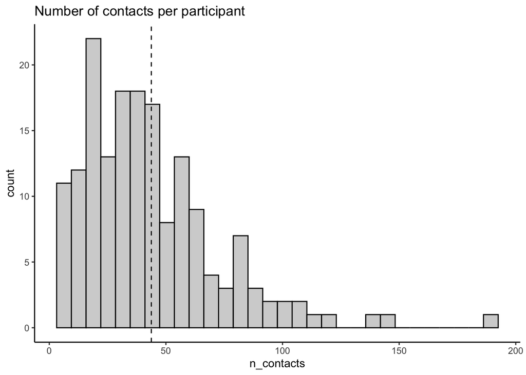

```r
contacts %>%
  group_by(subid) %>%
  summarise(n_contacts = length(unique(phone_number))) %>%
  ggplot(aes(x = n_contacts)) +
  geom_histogram(color = "black", fill = "light grey") +
  labs(title = "Number of contacts per participant") +
  geom_vline(aes(xintercept = mean(n_contacts)), contacts %>%
               group_by(subid) %>%
               summarise(n_contacts = length(unique(phone_number))), linetype = "dashed")
```

Number of contacts per subid faceted by spam vs not spam

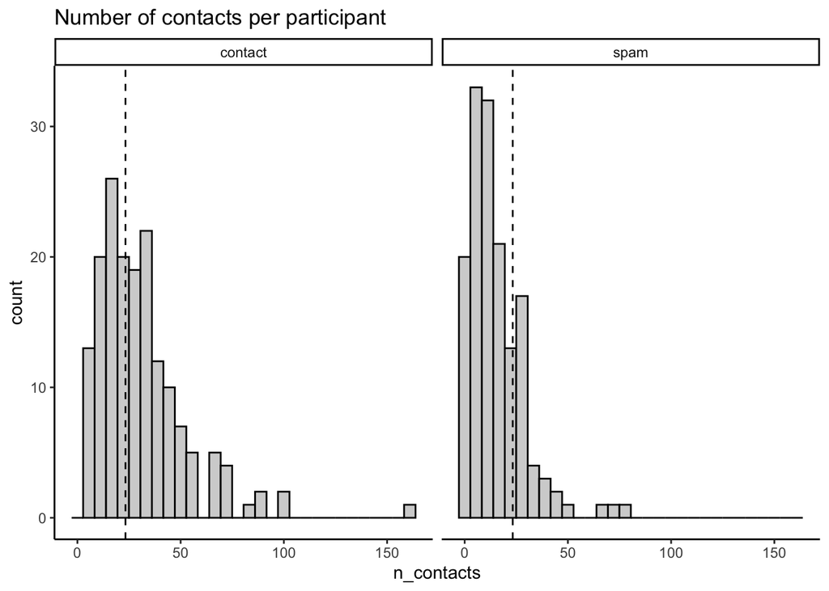

```r
contacts %>%
  mutate(spam = case_when(contact_type == "Irrelevant/Spam" ~ "spam",
                          TRUE ~ "contact")) %>%
  group_by(subid, spam) %>%
  summarise(n_contacts = length(unique(phone_number))) %>%
  ggplot(aes(x = n_contacts)) +
  geom_histogram(color = "black", fill = "light grey") +
  facet_wrap(~ spam) +
  labs(title = "Number of contacts per participant") +
  geom_vline(aes(xintercept = mean(n_contacts)), contacts %>%
               mutate(spam = case_when(contact_type == "Irrelevant/Spam" ~ "spam",
                          TRUE ~ "contact")) %>%
               group_by(subid, spam) %>%
               summarise(n_contacts = length(unique(phone_number))), linetype = "dashed")
```

### Write CSV

```r
write_csv(contacts, file.path(path_shared, "contacts.csv")) %>%
  glimpse()
```

```
## Rows: 7,413
## Columns: 15
## $ subid                <dbl> 1, 1, 1, 1, 1, 1, 1, 1, 1, 2, 2, 2, 2, 2, 2, 2, …
## $ utc                  <chr> "1487871000", "1487871000", "1487871000", "14878…
## $ contact_type         <chr> "Self", "Parent", "Other", "Friend", "Co-Worker/…
## $ phone_type           <chr> "cell_phone", "home_phone", "cell_phone", "cell_…
## $ phone_number         <chr> "6083588174", "6082227282", "6085149557", "60843…
## $ contact_drank_past   <chr> NA, "Never/Almost Never", "Never/Almost Never", …
## $ drink_status         <chr> NA, "Drinker", "NonDrinker", "NonDrinker", "Dont…
## $ contact_drink_future <chr> NA, "Yes", "No", "No", "No", "Yes", "Yes", "No",…
## $ recovery             <chr> NA, "No", "Yes", "Dont Know", "Yes", "No", "No",…
## $ support_status       <chr> NA, "Supportive", "Neutral", "Supportive", "Supp…
## $ contact_experience   <chr> NA, "Mixed", "Mixed", "Pleasant", "Pleasant", "P…
## $ monthly_visit        <chr> NA, NA, NA, NA, NA, NA, NA, NA, NA, NA, NA, NA, …
## $ street_address       <chr> NA, NA, NA, NA, NA, NA, NA, NA, NA, NA, NA, NA, …
## $ city                 <chr> NA, NA, NA, NA, NA, NA, NA, NA, NA, NA, NA, NA, …
## $ state                <chr> NA, NA, NA, NA, NA, NA, NA, NA, NA, NA, NA, NA, …
```